# ChipSeq

## ChIP-seq

ChIP-seq is a protocol for inferring the locations of proteins bound or associated with DNA. In the data the NGS reads form tall “peaks” at the locations where the proteins were bound to DNA in the cells which were used to create the sample. More specifically, ChIP-seq results in two peaks of reads of different strands.  
`DiffBind` package will be used.

```r
library(DiffBind)
setwd(system.file("extra", package="DiffBind"))
list.files()
```

```
FALSE [1] "config.csv"              "peaks"
FALSE [3] "tamoxifen.csv"           "tamoxifen_allfields.csv"
FALSE [5] "tamoxifen_GEO.csv"       "tamoxifen_GEO.R"
FALSE [7] "testdata"
```

```r
read.csv("tamoxifen.csv")
```

```
FALSE    SampleID Tissue Factor  Condition  Treatment Replicate
FALSE 1    BT4741  BT474     ER  Resistant Full-Media         1
FALSE 2    BT4742  BT474     ER  Resistant Full-Media         2
FALSE 3     MCF71   MCF7     ER Responsive Full-Media         1
FALSE 4     MCF72   MCF7     ER Responsive Full-Media         2
FALSE 5     MCF73   MCF7     ER Responsive Full-Media         3
FALSE 6     T47D1   T47D     ER Responsive Full-Media         1
FALSE 7     T47D2   T47D     ER Responsive Full-Media         2
FALSE 8    MCF7r1   MCF7     ER  Resistant Full-Media         1
FALSE 9    MCF7r2   MCF7     ER  Resistant Full-Media         2
FALSE 10    ZR751   ZR75     ER Responsive Full-Media         1
FALSE 11    ZR752   ZR75     ER Responsive Full-Media         2
FALSE                      bamReads ControlID                  bamControl
FALSE 1  reads/Chr18_BT474_ER_1.bam    BT474c reads/Chr18_BT474_input.bam
FALSE 2  reads/Chr18_BT474_ER_2.bam    BT474c reads/Chr18_BT474_input.bam
FALSE 3   reads/Chr18_MCF7_ER_1.bam     MCF7c  reads/Chr18_MCF7_input.bam
FALSE 4   reads/Chr18_MCF7_ER_2.bam     MCF7c  reads/Chr18_MCF7_input.bam
FALSE 5   reads/Chr18_MCF7_ER_3.bam     MCF7c  reads/Chr18_MCF7_input.bam
FALSE 6   reads/Chr18_T47D_ER_1.bam     T47Dc  reads/Chr18_T47D_input.bam
FALSE 7   reads/Chr18_T47D_ER_2.bam     T47Dc  reads/Chr18_T47D_input.bam
FALSE 8   reads/Chr18_TAMR_ER_1.bam     TAMRc  reads/Chr18_TAMR_input.bam
FALSE 9   reads/Chr18_TAMR_ER_2.bam     TAMRc  reads/Chr18_TAMR_input.bam
FALSE 10  reads/Chr18_ZR75_ER_1.bam     ZR75c  reads/Chr18_ZR75_input.bam
FALSE 11  reads/Chr18_ZR75_ER_2.bam     ZR75c  reads/Chr18_ZR75_input.bam
FALSE                      Peaks PeakCaller
FALSE 1  peaks/BT474_ER_1.bed.gz        bed
FALSE 2  peaks/BT474_ER_2.bed.gz        bed
FALSE 3   peaks/MCF7_ER_1.bed.gz        bed
FALSE 4   peaks/MCF7_ER_2.bed.gz        bed
FALSE 5   peaks/MCF7_ER_3.bed.gz        bed
FALSE 6   peaks/T47D_ER_1.bed.gz        bed
FALSE 7   peaks/T47D_ER_2.bed.gz        bed
FALSE 8   peaks/TAMR_ER_1.bed.gz        bed
FALSE 9   peaks/TAMR_ER_2.bed.gz        bed
FALSE 10  peaks/ZR75_ER_1.bed.gz        bed
FALSE 11  peaks/ZR75_ER_2.bed.gz        bed
```

```r
list.files("peaks")
```

```
FALSE  [1] "BT474_ER_1.bed.gz" "BT474_ER_2.bed.gz" "MCF7_ER_1.bed.gz"
FALSE  [4] "MCF7_ER_2.bed.gz"  "MCF7_ER_3.bed.gz"  "T47D_ER_1.bed.gz"
FALSE  [7] "T47D_ER_2.bed.gz"  "TAMR_ER_1.bed.gz"  "TAMR_ER_2.bed.gz"
FALSE [10] "ZR75_ER_1.bed.gz"  "ZR75_ER_2.bed.gz"
```

```r
setwd(system.file("extra", package="DiffBind"))
ta <- dba(sampleSheet="tamoxifen.csv")
ta
```

```
FALSE 11 Samples, 2845 sites in matrix (3795 total):
FALSE        ID Tissue Factor  Condition  Treatment Replicate Caller Intervals
FALSE 1  BT4741  BT474     ER  Resistant Full-Media         1    bed      1080
FALSE 2  BT4742  BT474     ER  Resistant Full-Media         2    bed      1122
FALSE 3   MCF71   MCF7     ER Responsive Full-Media         1    bed      1556
FALSE 4   MCF72   MCF7     ER Responsive Full-Media         2    bed      1046
FALSE 5   MCF73   MCF7     ER Responsive Full-Media         3    bed      1339
FALSE 6   T47D1   T47D     ER Responsive Full-Media         1    bed       527
FALSE 7   T47D2   T47D     ER Responsive Full-Media         2    bed       373
FALSE 8  MCF7r1   MCF7     ER  Resistant Full-Media         1    bed      1438
FALSE 9  MCF7r2   MCF7     ER  Resistant Full-Media         2    bed       930
FALSE 10  ZR751   ZR75     ER Responsive Full-Media         1    bed      2346
FALSE 11  ZR752   ZR75     ER Responsive Full-Media         2    bed      2345
```

Access the peaks for each file:

```r
names(ta)
```

```
FALSE  [1] "config"      "chrmap"      "peaks"       "class"       "masks"
FALSE  [6] "samples"     "called"      "totalMerged" "merged"      "binding"
FALSE [11] "attributes"  "minOverlap"
```

```r
class(ta$peaks)
```

```
FALSE [1] "list"
```

```r
head(ta$peaks[[1]])
```

```
FALSE      V1     V2     V3         V5
FALSE 1 chr18 215562 216063 0.01742633
FALSE 2 chr18 311530 312105 0.06909971
FALSE 3 chr18 356656 357315 0.02859148
FALSE 4 chr18 371110 372092 0.03846775
FALSE 5 chr18 395116 396464 0.47995863
FALSE 6 chr18 399014 400382 0.56996310
```

## Differential binding

Count the reads from the BAM files specified in the `samples` slot

```r
ta$samples
```

```
FALSE    SampleID Tissue Factor  Condition  Treatment Replicate
FALSE 1    BT4741  BT474     ER  Resistant Full-Media         1
FALSE 2    BT4742  BT474     ER  Resistant Full-Media         2
FALSE 3     MCF71   MCF7     ER Responsive Full-Media         1
FALSE 4     MCF72   MCF7     ER Responsive Full-Media         2
FALSE 5     MCF73   MCF7     ER Responsive Full-Media         3
FALSE 6     T47D1   T47D     ER Responsive Full-Media         1
FALSE 7     T47D2   T47D     ER Responsive Full-Media         2
FALSE 8    MCF7r1   MCF7     ER  Resistant Full-Media         1
FALSE 9    MCF7r2   MCF7     ER  Resistant Full-Media         2
FALSE 10    ZR751   ZR75     ER Responsive Full-Media         1
FALSE 11    ZR752   ZR75     ER Responsive Full-Media         2
FALSE                      bamReads ControlID                  bamControl
FALSE 1  reads/Chr18_BT474_ER_1.bam    BT474c reads/Chr18_BT474_input.bam
FALSE 2  reads/Chr18_BT474_ER_2.bam    BT474c reads/Chr18_BT474_input.bam
FALSE 3   reads/Chr18_MCF7_ER_1.bam     MCF7c  reads/Chr18_MCF7_input.bam
FALSE 4   reads/Chr18_MCF7_ER_2.bam     MCF7c  reads/Chr18_MCF7_input.bam
FALSE 5   reads/Chr18_MCF7_ER_3.bam     MCF7c  reads/Chr18_MCF7_input.bam
FALSE 6   reads/Chr18_T47D_ER_1.bam     T47Dc  reads/Chr18_T47D_input.bam
FALSE 7   reads/Chr18_T47D_ER_2.bam     T47Dc  reads/Chr18_T47D_input.bam
FALSE 8   reads/Chr18_TAMR_ER_1.bam     TAMRc  reads/Chr18_TAMR_input.bam
FALSE 9   reads/Chr18_TAMR_ER_2.bam     TAMRc  reads/Chr18_TAMR_input.bam
FALSE 10  reads/Chr18_ZR75_ER_1.bam     ZR75c  reads/Chr18_ZR75_input.bam
FALSE 11  reads/Chr18_ZR75_ER_2.bam     ZR75c  reads/Chr18_ZR75_input.bam
FALSE                      Peaks PeakCaller
FALSE 1  peaks/BT474_ER_1.bed.gz        bed
FALSE 2  peaks/BT474_ER_2.bed.gz        bed
FALSE 3   peaks/MCF7_ER_1.bed.gz        bed
FALSE 4   peaks/MCF7_ER_2.bed.gz        bed
FALSE 5   peaks/MCF7_ER_3.bed.gz        bed
FALSE 6   peaks/T47D_ER_1.bed.gz        bed
FALSE 7   peaks/T47D_ER_2.bed.gz        bed
FALSE 8   peaks/TAMR_ER_1.bed.gz        bed
FALSE 9   peaks/TAMR_ER_2.bed.gz        bed
FALSE 10  peaks/ZR75_ER_1.bed.gz        bed
FALSE 11  peaks/ZR75_ER_2.bed.gz        bed
```

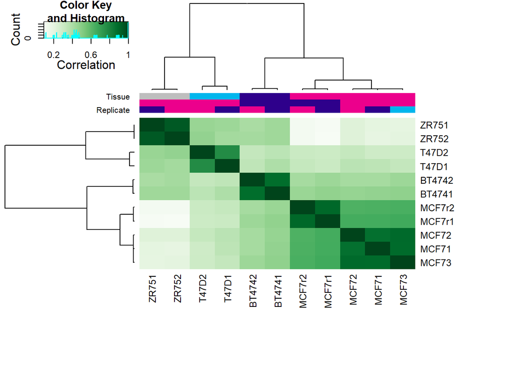

```r
# load the counts:
data(tamoxifen_counts)
ta2 <- tamoxifen
plot(ta2)
```

Correlation plot of differential binding.

```r
ta2 <- dba.contrast(ta2, categories=DBA_CONDITION)
ta2 <- dba.analyze(ta2)
ta2
```

```
FALSE 11 Samples, 2845 sites in matrix:
FALSE        ID Tissue Factor  Condition  Treatment Replicate Caller Intervals FRiP
FALSE 1  BT4741  BT474     ER  Resistant Full-Media         1 counts      2845 0.16
FALSE 2  BT4742  BT474     ER  Resistant Full-Media         2 counts      2845 0.15
FALSE 3   MCF71   MCF7     ER Responsive Full-Media         1 counts      2845 0.27
FALSE 4   MCF72   MCF7     ER Responsive Full-Media         2 counts      2845 0.17
FALSE 5   MCF73   MCF7     ER Responsive Full-Media         3 counts      2845 0.23
FALSE 6   T47D1   T47D     ER Responsive Full-Media         1 counts      2845 0.10
FALSE 7   T47D2   T47D     ER Responsive Full-Media         2 counts      2845 0.06
FALSE 8  MCF7r1   MCF7     ER  Resistant Full-Media         1 counts      2845 0.20
FALSE 9  MCF7r2   MCF7     ER  Resistant Full-Media         2 counts      2845 0.13
FALSE 10  ZR751   ZR75     ER Responsive Full-Media         1 counts      2845 0.32
FALSE 11  ZR752   ZR75     ER Responsive Full-Media         2 counts      2845 0.22
FALSE
FALSE 1 Contrast:
FALSE      Group1 Members1     Group2 Members2 DB.DESeq2
FALSE 1 Resistant        4 Responsive        7       629
```

Generate the results table, which is attached as metadata columns to the peaks as genomic ranges. By specifying `bCounts = TRUE`,obtain the normalized counts for each sample.

```r
tadb <- dba.report(ta2)
tadb
```

```
FALSE GRanges object with 629 ranges and 6 metadata columns:
FALSE        seqnames            ranges strand |      Conc Conc_Resistant
FALSE           <Rle>         <IRanges>  <Rle> | <numeric>      <numeric>
FALSE   2452    chr18 64490686-64491186      * |      6.36           1.39
FALSE   1291    chr18 34597713-34598213      * |      5.33           0.22
FALSE    976    chr18 26860997-26861497      * |      7.30           3.13
FALSE   2338    chr18 60892900-60893400      * |      7.13           1.84
FALSE   2077    chr18 55569087-55569587      * |      5.52           1.89
FALSE    ...      ...               ...    ... .       ...            ...
FALSE    551    chr18 14465945-14466445      * |      6.02           4.38
FALSE   2659    chr18 71909888-71910388      * |      5.58           3.73
FALSE   2541    chr18 68007206-68007706      * |      3.61           2.41
FALSE   1967    chr18 52609747-52610247      * |      3.87           2.39
FALSE   2383    chr18 61927095-61927595      * |      1.72          -0.22
FALSE        Conc_Responsive      Fold   p-value       FDR
FALSE              <numeric> <numeric> <numeric> <numeric>
FALSE   2452            7.00     -5.61  3.57e-10  1.02e-06
FALSE   1291            5.97     -5.75  1.10e-09  1.57e-06
FALSE    976            7.92     -4.79  1.10e-08  1.05e-05
FALSE   2338            7.77     -5.93  1.68e-08  1.17e-05
FALSE   2077            6.13     -4.23  2.36e-08  1.17e-05
FALSE    ...             ...       ...       ...       ...
FALSE    551            6.49     -2.11    0.0108    0.0490
FALSE   2659            6.07     -2.34    0.0108    0.0491
FALSE   2541            4.01     -1.60    0.0109    0.0495
FALSE   1967            4.32     -1.94    0.0109    0.0495
FALSE   2383            2.22     -2.44    0.0110    0.0498
FALSE   -------
FALSE   seqinfo: 1 sequence from an unspecified genome; no seqlengths
```

```r
counts <- dba.report(ta2, bCounts=TRUE)
```

## Log fold transform

```r
x <- mcols(counts)[1,-c(1:6)]
x <- unlist(x)
(xord <- x[match(ta2$samples$SampleID, names(x))])
```

```
FALSE BT4741 BT4742  MCF71  MCF72  MCF73  T47D1  T47D2 MCF7r1 MCF7r2  ZR751  ZR752
FALSE   2.26   2.24 231.00 124.43 191.64  10.38   5.51   2.35   3.62 177.91 153.27
```

```r
# Bioc 2.13 can use this line:
# (xord <- x[order(c(which(ta2$samples$Condition == "Resistant"),which(ta2$samples$Condition == "Responsive")))])
ta2$samples$SampleID
```

```
FALSE  [1] "BT4741" "BT4742" "MCF71"  "MCF72"  "MCF73"  "T47D1"  "T47D2"  "MCF7r1"
FALSE  [9] "MCF7r2" "ZR751"  "ZR752"
```

Create a vector of the conditions, and conditions combined with tissue:

```r
cond <- factor(ta2$samples[,"Condition"])
condcomb <- factor(paste(ta2$samples[,"Condition"], ta2$samples[,"Tissue"]))
```

A stripchart of the counts over the conditions:

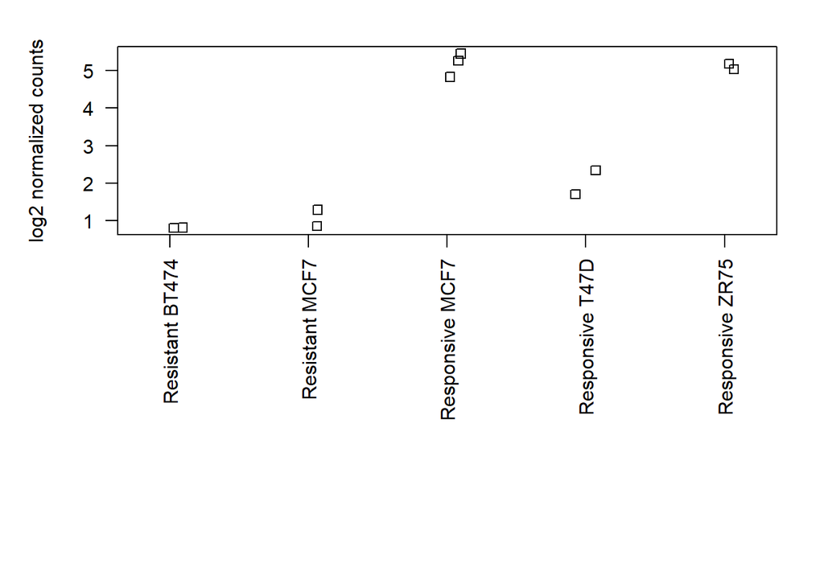

```r
par(mar=c(15,5,2,2))
stripchart(log(xord) ~ condcomb, method="jitter",
           vertical=TRUE, las=2, ylab="log2 normalized counts")
```

Finally, we show that the log2 fold change of the means is the same as reported by the `DiffBind` functions:

```r
means <- tapply(xord, cond, mean)
log2(means)
```

```
FALSE  Resistant Responsive
FALSE   1.388190   6.997002
```

```r
log2(means[1] / means[2])
```

```
FALSE Resistant
FALSE -5.608812
```

```r
mcols(tadb)[1,]
```

```
FALSE DataFrame with 1 row and 6 columns
FALSE           Conc Conc_Resistant Conc_Responsive      Fold   p-value       FDR
FALSE      <numeric>      <numeric>       <numeric> <numeric> <numeric> <numeric>
FALSE 2452      6.36           1.39               7     -5.61  3.57e-10  1.02e-06
```

### Model-based Analysis for ChIP-Seq (MACS)

reference: http://www.ncbi.nlm.nih.gov/pmc/articles/PMC2592715/